# Lecture 6: Introduction to bulk-RNAseq DE Analysis: Visualizations and Downstream Applications

Megan Stumpf

10/18/2022

# 1. Objectives and Goals

The primary objective of this assignment is to illustrate that you understand the final steps of bulk-RNAseq data processing as it pertains to data clean up, modelling and differential gene expression analysis. By the end of this lecture and assignment you should be able to:

- generate results and volcano plots of differentially expressed genes between different biological groups
- generate heatmaps of expression on normalized dataset
- perform enrichment and pathway analysis
- create visuals to illustrate enrichment and pathway analysis results

# 2. Install/Load packages

This section is always required. You will load all packages necessary for the scope of the assignment in between the code blocks.

Write code to load in the following R packages:

- tidyverse
- ggrepel
- pheatmap
- RColorBrewer
- msigdbr
- org.Mm.eg.db
- clusterProfiler
- ggnewscale

```r
# TO DO
library(tidyverse)
library(ggrepel)
library(pheatmap)
library(RColorBrewer)
library(msigdbr)
library(org.Mm.eg.db)
library(clusterProfiler)
library(ggnewscale)
```

# 3. Bulk RNA-seq Downstream Analysis and Visualizations

**Purpose**: The purpose here is be able to write code to generate and customize volcano plots for differential gene expression analysis. Additionally, by the end of the assignment, you should also be able to perform additional downstream analysis on differential gene expression data outputs and various visualizations.

## 3.1 Volcano Plot

1. Perform the following tasks to create a volcano plot of your data:
1. Read in your csv differential expression results file and store it in a variable.
2. create a column in your differential expression results data frame called -log10FDR and calculate the -log10FDR values
3. create a column in your differential expression results data frame called gene and have it list all the gene names
4. create a volcano plot of log2(foldChange) on the x-axis and negLog10FDR on the y-axis. Create a horizontal line that is equal to a neglog10(FDR) to neglog10(0.10), and 2 vertical lines, one where log2(FC) == 1 and one where log2(FC) == -1 and add labels to all genes that have an adjust p-value of less than 0.10.

```r
# TO DO
# My DE data already exists as a data frame so rereading in as a new variable here
## A
DEdataf <- read.csv(file = "~/bulkRNAseq/L5/30min_n4_prn694_vs_30min_n4.csv", header = TRUE, sep = ",")
rownames(DEdataf) <- DEdataf$X
head(DEdataf)
```

```
##                           X    baseMean log2FoldChange     lfcSE        stat
## Zc3h14               Zc3h14  375.461015   -0.003607673 0.1965079 -0.01835892
## Troap                 Troap    4.086629    2.238180983 1.7434382  1.28377420
## 1810013L24Rik 1810013L24Rik  842.637125   -0.196572476 0.4866797 -0.40390523
## Srsf7                 Srsf7 4222.636917    0.069723627 0.2123762  0.32830252
## Anapc15             Anapc15  371.166262    0.282816249 0.1597955  1.76986396
## Nmb                     Nmb  101.062491   -0.089020864 0.3892905 -0.22867463
##                   pvalue padj
## Zc3h14        0.98535252    1
## Troap         0.19922097    1
## 1810013L24Rik 0.68628241    1
## Srsf7         0.74268294    1
## Anapc15       0.07674981    1
## Nmb           0.81912181    1
```

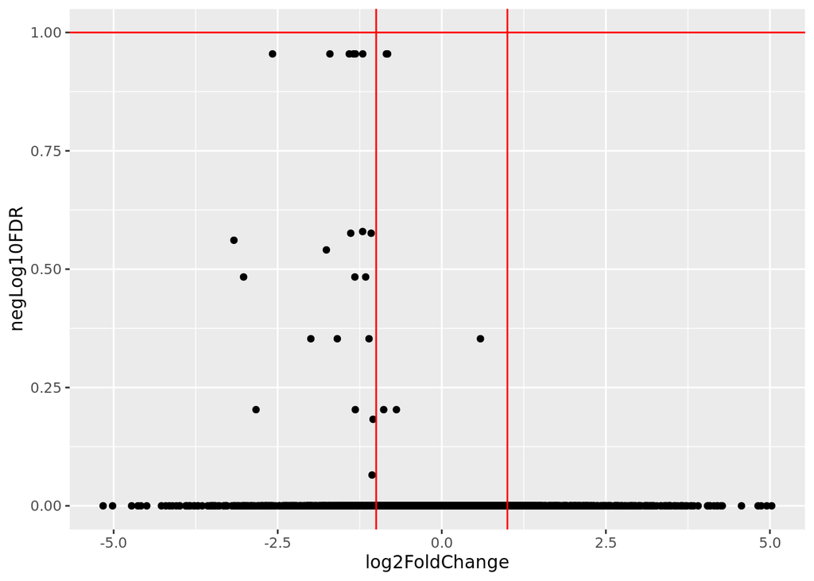

```r
## B
DEdataf$negLog10FDR <- (-1) * log10(DEdataf$padj)
## C
DEdataf$gene <- rownames(DEdataf)
## D
ggplot(DEdataf, aes(x = log2FoldChange, y = negLog10FDR)) +
      geom_point() +
      geom_vline(xintercept=c(-1, 1), col="red") +
      geom_hline(yintercept= (-1) * log10(0.10), col="red") +
      geom_text_repel(data=subset(DEdataf, padj < 0.10), aes(label = gene))
```

## 3.2 Heatmap

2. Create a heatmap of using your normalized reads of all the genes that have a padj value < 0.10 by performing the following steps:
1. Read in your normalized counts dataframe
2. get all the gene names that have a padj < 0.10 and store them in a list
3. create a variable that store the list of sample names to plot in the heatmap
4. subset your normalized counts dataframe to only select samples and significant genes to plot in the heatmap and generate a color palette
5. generate heatmap

```r
# TO DO

# KNIT IS NOT LETTING THIS CHUNK EXECUTE SAYING THE OBJECT DOES NOT EXIST BUT IT WORKS FINE IN MY ENVIRONMENT. I THINK THIS GOT SCREWED UP WHEN WE CLEARED MY ENVIRONMENT TOGETHER. I CAN SHOW YOU THE OUTPUT ON MY COMPUTER.
normCountsDf2
sigGenes <- DEdataf[DEdataf$padj < 0.20, "gene"]
sigGenesOmit <- na.omit(sigGenes)
samplesOfInterest <- c("30_min_N4_peptide_PRN-694_rep1",
                       "30_min_N4_peptide_PRN-694_rep2",
                       "30_min_N4_peptide_PRN-694_rep3",
                       "30_min_N4_peptide_rep1",
                       "30_min_N4_peptide_rep2",
                       "30_min_N4_peptide_rep3")
dataToGraph <- normCountsDf2[sigGenesOmit, samplesOfInterest]
pal <- colorRampPalette(c("#6aa84f", "white", "#ffff00"))
pheatmap(dataToGraph,
 show_rownames = TRUE,
 scale = 'row',
 cluster_cols = TRUE,
 cluster_rows = TRUE,
 angle_col = 45,
 cellwidth = 25,
 cellheight = 10,
 color = pal(20),
 display_numbers = FALSE
 )
```

[output not shown]

## 3.3 Enrichment and pathway analysis

3. Perform the following tasks as they pertain data preparation for input in to enrichment and pathway analysis:
1. create a new dataframe with only results meeting FDR < 0.10
2. create a new list from the dataframe in (a) that extracts the log2FoldChange values
3. name the elements in the list by gene name
4. sort the list in decreasing order

```r
# TO DO

deGenes <- DEdataf[DEdataf$padj < 0.20, ]
deGenes <- na.omit(deGenes)
logFoldGenes <- deGenes$log2FoldChange
names(logFoldGenes) <- deGenes$gene
logFoldGenes <- sort(logFoldGenes, decreasing = TRUE)
```

4. Perform the following tasks as they pertain database extraction from reference set:
1. generate a mouse database from the Hallmark Gene Set
2. generate a mouse database from the GO/KEGG gene set
3. generate a mouse database from the immunological signatures gene set

```r
# TO DO

#A
msigH_mouse <- msigdbr(species = "Mus musculus", category = "H") %>%
 dplyr::select(gs_name, gene_symbol)

#B
msigC5_mouse <- msigdbr(species = "Mus musculus", category = "C5") %>%
 dplyr::select(gs_name, gene_symbol)

#C
msigC7_mouse <- msigdbr(species = "Mus musculus", category = "C7") %>%
 dplyr::select(gs_name, gene_symbol)
```

5. Perform the following tasks as they pertain to the identification of genes enriched in the Hallmark Gene Set:
1. Run gene enrichment analysis on your list of genes above
2. Write code to save your output to a csv file
3. Create a dotplot of the top 10 categories with the color of the dot represeting p.adjust and the x-axis represnting the GeneRatio. Title it: “30min N4 PRN694 relative to 30min N4 - Hallmark Enrichment”

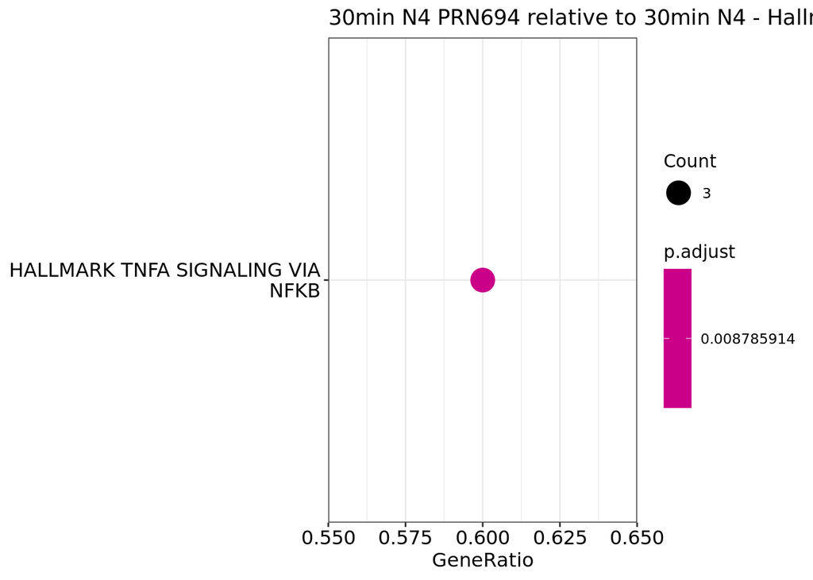

```r
# TO DO
outputH <- enricher(gene = names(logFoldGenes), TERM2GENE = msigH_mouse)
gsea_hallmark_results <- outputH@result
write.csv(gsea_hallmark_results, file = "~/bulkRNAseq/L6/outputH.csv")
dotplot(outputH, showCategory=10, x="GeneRatio", color="p.adjust", title="30min N4 PRN694 relative to 30min N4 - Hallmark Enrichment")
```

6. Perform the following tasks as they pertain to the identification of genes enriched in the GO/Kegg Gene Set:
1. Run gene enrichment analysis on your list of genes above.
2. Write code to save your output to a csv file
3. Create a dotplot of the top 10 categories with the color of the dot represeting p.adjust and the x-axis represnting the GeneRatio. Title it: “30min N4 PRN694 relative to 30min N4 - GO-KEGG Enrichment”

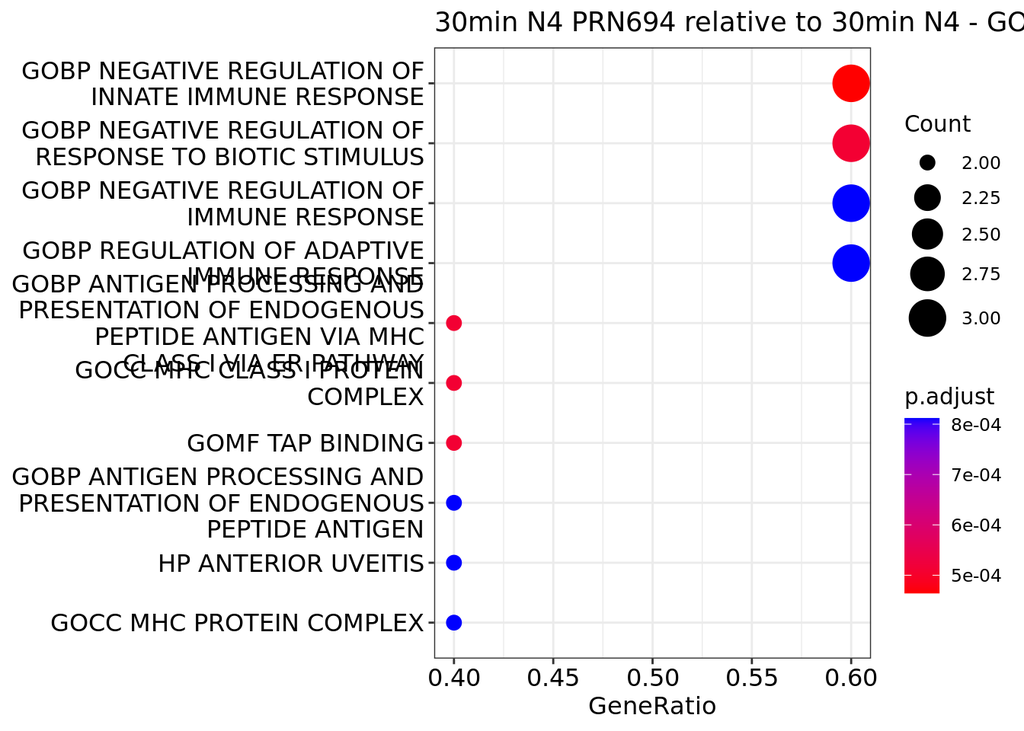

```r
# TO DO
outputC5 <- enricher(gene = names(logFoldGenes), TERM2GENE = msigC5_mouse)
gsea_kegg_results <- outputC5@result
write.csv(gsea_kegg_results, file = "~/bulkRNAseq/L6/outputC5.csv")
dotplot(outputC5, showCategory=10, x="GeneRatio", color="p.adjust", title="30min N4 PRN694 relative to 30min N4 - GO-KEGG Enrichment")
```

7. Perform the following tasks as they pertain to the identification of genes enriched in the Immunological Signatures Gene Set:
1. Run gene enrichment analysis on your list of genes above.
2. Write code to save your output to a csv file
3. Create a dotplot of the top 10 categories with the color of the dot represeting p.adjust and the x-axis represnting the GeneRatio. Title it: “30min N4 PRN694 relative to 30min N4 - Immuno Sig Enrichment”
4. Create a heatplot of the top 5 categories in the immunological signatures enriched terms
5. Create a cnetplot of the top 5 categories in the immunological signatures enriched terms

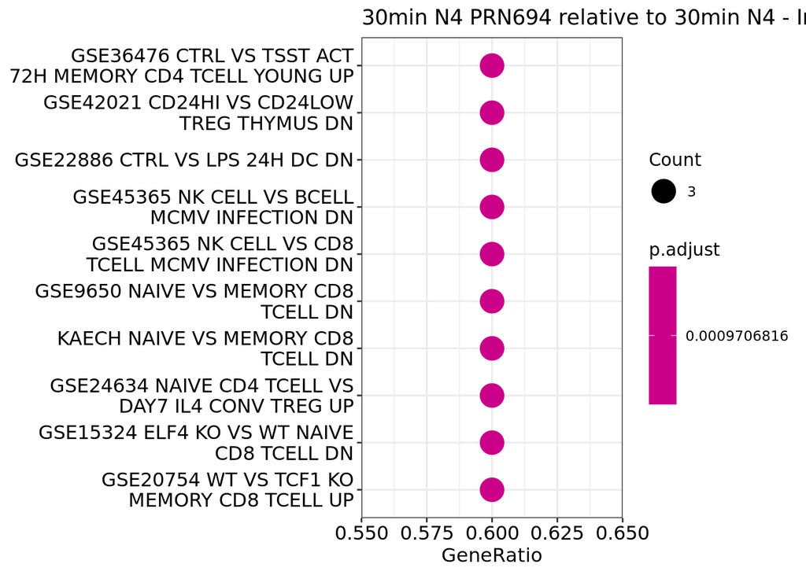

```r
# TO DO
outputC7 <- enricher(gene = names(logFoldGenes), TERM2GENE = msigC7_mouse)
gsea_immuno_results <- outputC7@result
write.csv(gsea_immuno_results, file = "~/bulkRNAseq/L6/outputC7.csv")
dotplot(outputC7, showCategory=10, x="GeneRatio", color="p.adjust", title="30min N4 PRN694 relative to 30min N4 - Immuno Sig Enrichment")
```

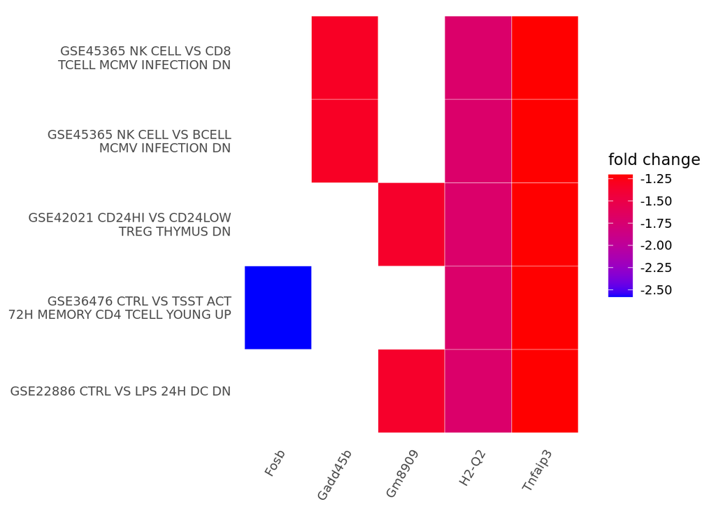

```r
heatplot(outputC7, foldChange=logFoldGenes, showCategory=5)
```

[figure not shown]

```r
cnetplot(outputC7, foldChange=logFoldGenes, showCategory=5, circular = TRUE,
colorEdge = TRUE)
```

## **Critical Thinking Exercises**

Based on your heatmap of differential expression between 30min_N4_PRN-694 relative to 30min_N4, name 3 genes that are upregulated in the 30min_N4_PRN-694 dataset but look downregulated in 30min_N4.

NOTE: Spoke with Tonya and we are troubleshooting my results so using what dataset was generated and set padj to <0.20 so it would graph some figures. Will be rerunning in the future and resubmitting to Tonya. The current results suggest none.

Compare and contrast the volcanco plot you generated from 30min_N4_PRN-694 relative to 30min_N4 compared to the Figure 4A in Gallagher et al 2021. Are the trends similar? Why does your volcano plot visually look like the opposite of the one generated in the figure? Explain why they are not really different.

The volcano plot will look like the opposite because the “denominator” in the differential expression object was the opposite of ours, so the results will look mirrored. This only changes the directionality of the change, not the actual interpretations. For this reason, they are not really different. However, my current volcano plot is incorrect (see answer to number 1) so making an educated guess.

Select one pathway that is enriched in the GO/Kegg gene set. What pathway is it and what genes are enriched in that pathway?

These results are not currently accurate but the current results suggest that the GOBP Negative Resultation of the Innate Immune Response pathway is enriched and the genes enriched in that pathway are: Tnfaip3/Gm8909/H2-Q2.

# 4. Session info

Finally, we will **always** end our Rmarkdown documents with the session information. This provides version control so if there is any issue with your code or results, we can trace it back to the session information and try running it on the same system. You just need to always include this section, although no changes will ever need to be made here.

[session information not shown]